# Data analysis

Albina Gibadullina

October 11, 2020

## Set Up

[View available packages in CRAN](https://cran.r-project.org/web/views/)

Information on current R version, operating system, loaded packages

```r
#sessionInfo()
```

Install packages for network analysis

```r
#install.packages("igraph", "network", "sna", "tidyverse", "scales", "plotly")
```

Upload all neccessary packages

```r
suppressPackageStartupMessages(library(tidyverse))
suppressPackageStartupMessages(library(scales))
suppressPackageStartupMessages(library(plotly))
```

Update all packages

```r
#update.packages()
```

To unload a package

```r
#detach("package:ggplot2", unload=TRUE)
```

To remove a package

```r
#remove.packages("ggplot2")
```

Get help on a package

```r
# help(package = "ggplot2")

#Get additional info for packages
# browseVignettes("ggplot2")
```

Update R version

```r
# install.packages("installr")
# library(installr)
# updateR()
```

## R Markdown Styles

**bold** *italics* strikethrough

# Header1

## Header2

### Header 3

#### Unordered list

- Item 1
- Item 2
  - Item 2a
  - Item 2b

#### Ordered list

1. Item 1
2. Item 2
3. Item 3
   - Item 3a
   - Item 3b

[linked phrase](http://example.com)

Inline equation: $5x+2$

Display equation:
$$5x+2$$

## Inputting data

```r
x <- 1
print(x) #explict printing
```

```
## [1] 1
```

```r
msg <- "hello"
msg #auto-printing
```

```
## [1] "hello"
```

```r
#Create a sequence of values
y <- 1:20
```

Creating vectors

```r
#Numeric data
x <- 1 # x equals 1
x <- 1L # specify that 1 is an integer

# infinity - Inf
1/Inf
```

```
## [1] 0
```

Creating Vectors

```r
# The c() function can be used to create vectors of objects

x1 <- c(0.5, 0.6) ## numeric
x2 <- c(TRUE, FALSE) ## logical
x3 <- c(T, F) ## logical
x4 <- c("a", "b", "c") ## character
x5 <- 9:29 ## integer
x6 <- c(1+0i, 2+4i) ## complex

# Using the vector() function
x7 <- vector("numeric", length = 10)
x1; x2; x3; x4; x5; x6; x7
```

```
## [1] 0.5 0.6
```

```
## [1]  TRUE FALSE
```

```
## [1]  TRUE FALSE
```

```
## [1] "a" "b" "c"
```

```
##  [1]  9 10 11 12 13 14 15 16 17 18 19 20 21 22 23 24 25 26 27 28 29
```

```
## [1] 1+0i 2+4i
```

```
##  [1] 0 0 0 0 0 0 0 0 0 0
```

Mixing Objects

```r
#When different objects are mixed in a vector, coercion occurs so that every element in the vector is of the same class.

y <- c(1.7, "a") ## convert 1.7 to character
y <- c(TRUE, 2) ## convert TRUE to numeric = 1
y <- c("a", TRUE) ## convert TRUE to character
```

Explicit Coercion

```r
#Objects can be explicitly coerced from one class to another using the as.* functions, if available.

x <- 0:6
class(x)
```

```
## [1] "integer"
```

```r
as.numeric(x)
```

```
## [1] 0 1 2 3 4 5 6
```

```r
as.logical(x)
```

```
## [1] FALSE  TRUE  TRUE  TRUE  TRUE  TRUE  TRUE
```

```r
as.character(x)
```

```
## [1] "0" "1" "2" "3" "4" "5" "6"
```

```r
#Nonsensical coercion results in NAs:

x <- c("a", "b", "c")
as.numeric(x)
```

```
## [1] NA NA NA
```

```r
as.logical(x)
```

```
## [1] NA NA NA
```

```r
as.complex(x)
```

```
## [1] NA NA NA
```

Matrices

```r
#Matrices are vectors with a dimension attribute. The dimension attribute is itself an integer vector of length 2 (nrow, ncol)

m <- matrix(nrow = 2, ncol = 3)
m
```

```
##      [,1] [,2] [,3]
## [1,]   NA   NA   NA
## [2,]   NA   NA   NA
```

```r
dim(m)
```

```
## [1] 2 3
```

```r
attributes(m)
```

```
## $dim
## [1] 2 3
```

```r
#Matrices are constructed column-wise, so entries can be thought of starting in the “upper left” corner and running down the columns.
m <- matrix(1:6, nrow = 2, ncol = 3)
m
```

```
##      [,1] [,2] [,3]
## [1,]    1    3    5
## [2,]    2    4    6
```

```r
#Matrices can also be created directly from vectors by adding a dimension attribute.
m <- 1:10
m
```

```
##  [1]  1  2  3  4  5  6  7  8  9 10
```

```r
dim(m) <- c(2, 5)
m
```

```
##      [,1] [,2] [,3] [,4] [,5]
## [1,]    1    3    5    7    9
## [2,]    2    4    6    8   10
```

```r
# cbind-ing and rbind-ing
## Matrices can be created by column-binding or row-binding with cbind() and rbind()

x <- 1:3
y <- 10:12
cbind(x, y)
```

```
##      x  y
## [1,] 1 10
## [2,] 2 11
## [3,] 3 12
```

```r
rbind(x, y)
```

```
##   [,1] [,2] [,3]
## x    1    2    3
## y   10   11   12
```

Lists

```r
#Lists are a special type of vector that can contain elements of different classes

x <- list(1, "a", TRUE, 1 + 4i)
x
```

```
## [[1]]
## [1] 1
##
## [[2]]
## [1] "a"
##
## [[3]]
## [1] TRUE
##
## [[4]]
## [1] 1+4i
```

Factors

```r
#Factors are used to represent categorical data. Factors can be unordered or ordered

x <- factor(c("yes", "yes", "no", "yes", "no"))
x
```

```
## [1] yes yes no  yes no
## Levels: no yes
```

```r
# frequency count summary
table(x)
```

```
## x
##  no yes
##   2   3
```

```r
# turn categorical data into integer data (how R sees categorical data)
unclass(x)
```

```
## [1] 2 2 1 2 1
## attr(,"levels")
## [1] "no"  "yes"
```

```r
#The order of the levels can be set using the levels argument to factor(). R lists levels alphabetically unless specified

x <- factor(c("yes", "yes", "no", "yes", "no"),
 levels = c("yes", "no"))
x
```

```
## [1] yes yes no  yes no
## Levels: yes no
```

Missing values

```r
# NA denotes missing values
# is.na() is used to test objects if they are NA

# NaN devotes undefined mathematical operations
# is.nan() is used to test for NaN

x <- c(1, 2, NA, 10, 3)
is.na(x)
```

```
## [1] FALSE FALSE  TRUE FALSE FALSE
```

```r
is.nan(x)
```

```
## [1] FALSE FALSE FALSE FALSE FALSE
```

```r
# A NaN value is also NA but the converse is not true

x <- c(1, 2, NaN, NA, 4)
is.na(x)
```

```
## [1] FALSE FALSE  TRUE  TRUE FALSE
```

```r
is.nan(x)
```

```
## [1] FALSE FALSE  TRUE FALSE FALSE
```

Data Frames

```r
# Data frames are used to store tabular data. Unlike matrices, data frames can store different classes of objects in each column (just like lists).

x <- data.frame(id = c("A", "B", "C", "D"), foo = 1:4, bar = c(T, T, F, F))

# row.names lists all the rows
row.names(x)
```

```
## [1] "1" "2" "3" "4"
```

```r
# measure number of rows
nrow(x)
```

```
## [1] 4
```

```r
# measure number of columns
ncol(x)
```

```
## [1] 3
```

```r
# read.table() or read.csv() to create a data frame

# data.matrix() to converte data frame to a matrix, coerces objects so that they are all the same!
```

Names

```r
#R objects can also have names, which is very useful for writing readable code and self-describing objects.

x <- 1:3
names(x) <- c("foo", "bar", "norf")

x
```

```
##  foo  bar norf
##    1    2    3
```

```r
names(x)
```

```
## [1] "foo"  "bar"  "norf"
```

```r
#Lists can also have names.
x <- list(a = 1, b = 2, c = 3)
x
```

```
## $a
## [1] 1
##
## $b
## [1] 2
##
## $c
## [1] 3
```

```r
names(x)
```

```
## [1] "a" "b" "c"
```

```r
#Matrics can also have names.
m <- matrix(1:4, nrow = 2, ncol = 2)
dimnames(m) <- list(c("a", "b"), c("c", "d"))
m
```

```
##   c d
## a 1 3
## b 2 4
```

### Reading data

There are a few principal functions reading data into R

- $read.table$, $read.csv$
  - for reading tabular data
- $readLines$
  - for reading lines of a text file
- source
  - for reading in R code files (inverse of dump)
- dget
  - for reading in R code files (inverse of dput)
- load
  - for reading in saved workspaces
- unserialize
  - for reading single R objects in binary form

### Writing Data

There are analogous functions for writing data to files

- write.table
  - for writing tabular data
- writeLines
  - for writing lines of a text file
- dump
  - for writing in R code files
- dput
  - for writing in R code files (inverse of dput)
- save
  - for saving in workspaces
- serialize
  - for writing single R objects in binary form

read.table arguments:

file, the name of a file, or a connection header, logical indicating if the file has a header line sep, a string indicating how the columns are separated colClasses, a character vector indicating the class of each column in the dataset nrows, the number of rows in the dataset comment.char, a character string indicating the comment character skip, the number of lines to skip from the beginning stringsAsFactors, should character variables be coded as factors?

## Distributions

Binomial distribution

```r
#Assign values to variables
n <- 500
p <- 0.1
X <- 50

#computes FY(y)
pbinom(X,n,p)
```

```
## [1] 0.5375688
```

```r
#computes fY(y)
dbinom(X,n,p)
```

```
## [1] 0.05937067
```

Normal approximation to the Binomial

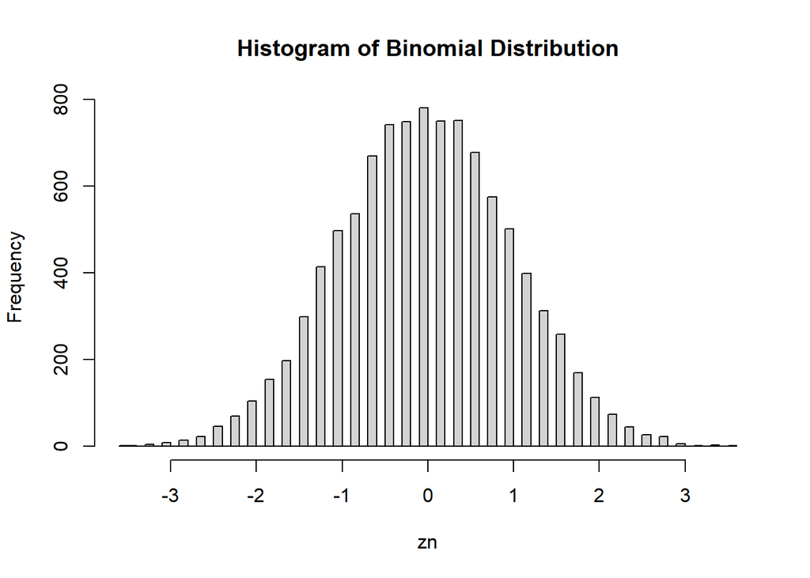

```r
# generate m i.i.d. binomial random variables
## rbinom - generation of a binomial distribution with specified paramters
p = 0.5; n = 100; m=10000;
yn = rbinom(m,n,p);

# standardize these variables
zn = (yn - n*p)/sqrt(p*(1-p)*n);

# draw the histogram
hist(zn,100,main=paste("Histogram of Binomial Distribution"))
```

Exponential distribution

```r
#Assign values to variables
y <- 5
lambda <- 2

#computes FY(y)
pexp(y, lambda)
```

```
## [1] 0.9999546
```

```r
#computes fY(y)
dexp(y, lambda)
```

```
## [1] 9.079986e-05
```

Poisson distribution

```r
#Assign values to variables
y <- 5
lambda <- 2

#computes FY(y)
ppois(y, lambda)
```

```
## [1] 0.9834364
```

```r
#computes fY(y)
dpois(y, lambda)
```

```
## [1] 0.03608941
```

Normal distribution

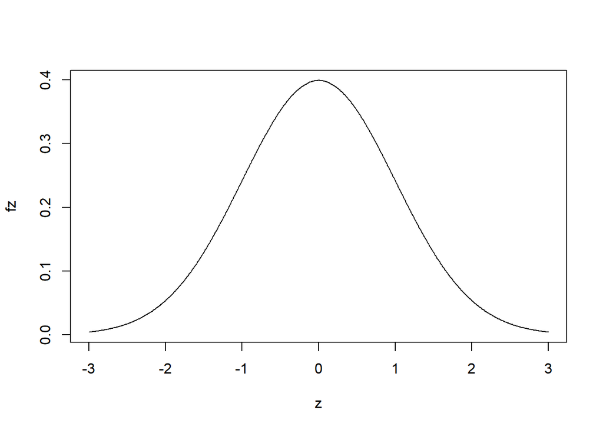

```r
#creates a vector (-3.00,-2.99,...,2.99,3.00)
z = seq(-3,3,0.01)

#computes the normal density at each point of z
fz = dnorm(z)

#plots z against fz (as a line)
plot(z, fz, type="l")
```

```r
#Assign values to variables
X <- 0.5
Mean <- 0
SD <- 1

#computes FY(y)
pnorm(X, Mean, SD, lower.tail=FALSE)
```

```
## [1] 0.3085375
```

```r
#computes fY(y)
dnorm(X, Mean, SD)
```

```
## [1] 0.3520653
```

```r
# set seed to reproduce the results
set.seed(123);

# generates n=3 random deviates, normal dist, finds mean

y1=rnorm(3,mean=2,sd=1); mean(y1);
```

```
## [1] 2.256018
```

```r
y2=rnorm(3,mean=2,sd=1); mean(y2);
```

```
## [1] 2.638287
```

```r
y3=rnorm(3,mean=2,sd=1); mean(y3);
```

```
## [1] 1.503001
```

```r
y4=rnorm(3,mean=2,sd=1); mean(y4);
```

```
## [1] 2.379411
```

```r
y5=rnorm(3,mean=2,sd=1); mean(y5);
```

```
## [1] 1.985204
```

Chi-square distribution

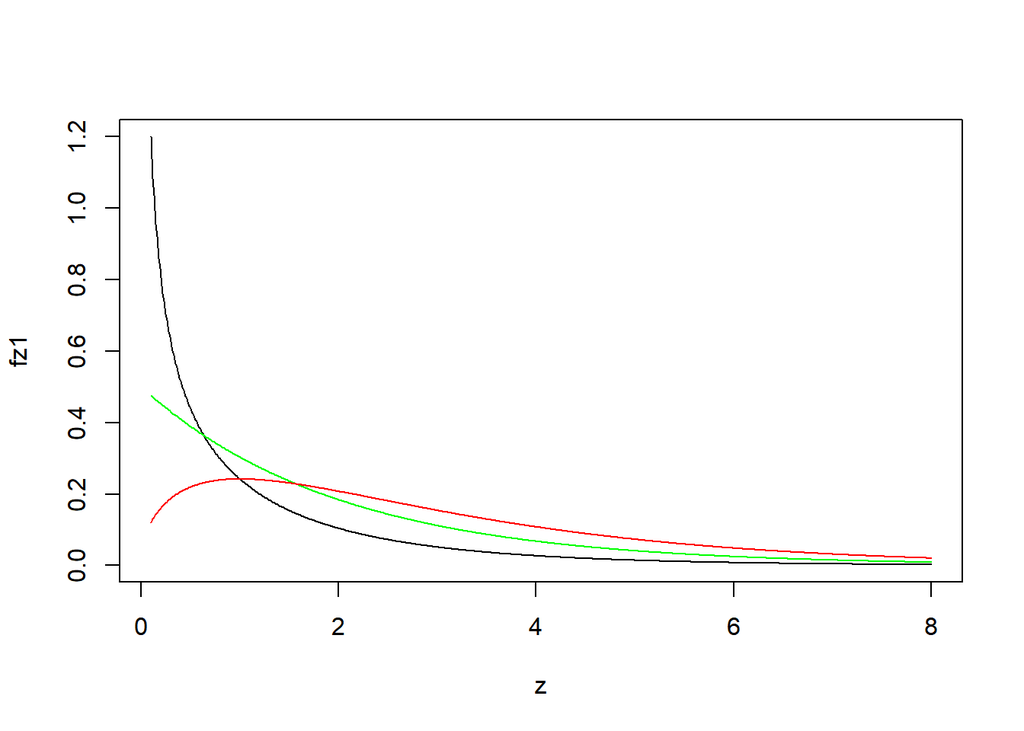

```r
# df is the number of degrees of freedom
z = seq(0.1,8,0.01);
fz1 = dchisq(z,df=1);
fz2 = dchisq(z,df=2);
fz3 = dchisq(z,df=3);

# plot distribution functions for different df
plot(z, fz1, type="l");
lines(z, fz2, col="green");
lines(z, fz3, col="red");
```

```r
#Assign values to variables
CI<- 0.95
df <- 10

#computes FY(y)
qchisq(CI, df)
```

```
## [1] 18.30704
```

```r
#computes fY(y)
dchisq(CI,df)
```

```
## [1] 0.0006595433
```

T-distribution

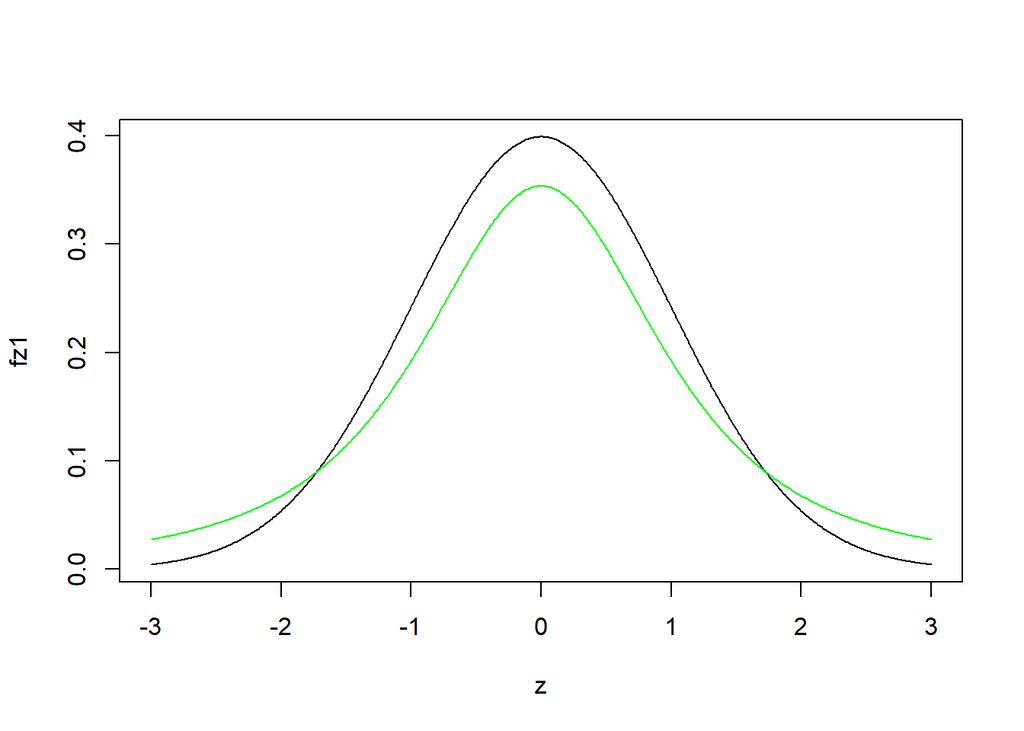

```r
z = seq(-3,3,0.01);
fz1 = dnorm(z);
fz2 = dt(z,df=2);
plot(z, fz1, type="l");
lines(z, fz2, type="l",col="green")
```